```python
# Standard Libraries

import numpy as np
import pandas as pd
import warnings
warnings.filterwarnings('ignore')

# For visualizations
import matplotlib.pyplot as plt
import seaborn as sns
%matplotlib inline
import plotly.offline as py
py.init_notebook_mode(connected=True)
import plotly.graph_objs as go
import plotly.tools as tls


# For Web Scrapping
import requests
from bs4 import BeautifulSoup

# For Data Pre-processing
import re
import nltk
from nltk.corpus import stopwords
from sklearn.feature_extraction.text import CountVectorizer
from textblob import Word, TextBlob
from wordcloud import WordCloud , STOPWORDS

# For topic modeling
from sklearn.decomposition import NMF, LatentDirichletAllocation

# For sentiment analysis
from vaderSentiment.vaderSentiment import SentimentIntensityAnalyzer
analyzer = SentimentIntensityAnalyzer()
```

# Extracting reviews from "Skytrax" website

```python
website = "https://www.airlinequality.com/airline-reviews/british-airways"
pages = 50              # Total no. of pages selected for review extraction
page_size = 100

reviews = []            # object to store extracted reviews from website

for i in range(1, pages + 1):

    print(f"Scraping data from Page {i}")

    # Create URL to collect links
    url = f"{website}/page/{i}/?sortby=post_date%3ADesc&pagesize={page_size}"


    response = requests.get(url)     # Collect HTML data from this page

    # Parse content
    content = response.content
    parsed_content = BeautifulSoup(content, 'html.parser')
    for para in parsed_content.find_all("div", {"class": "text_content"}):
        reviews.append(para.get_text())

    print(f"   ---> {len(reviews)} Total Reviews")
```

```
Scraping data from Page 1
   ---> 100 Total Reviews
Scraping data from Page 2
   ---> 200 Total Reviews
Scraping data from Page 3
   ---> 300 Total Reviews
Scraping data from Page 4
   ---> 400 Total Reviews
Scraping data from Page 5
   ---> 500 Total Reviews
Scraping data from Page 6
   ---> 600 Total Reviews
Scraping data from Page 7
   ---> 700 Total Reviews
Scraping data from Page 8
   ---> 800 Total Reviews
Scraping data from Page 9
   ---> 900 Total Reviews
Scraping data from Page 10
   ---> 1000 Total Reviews
Scraping data from Page 11
   ---> 1100 Total Reviews
Scraping data from Page 12
   ---> 1200 Total Reviews
Scraping data from Page 13
   ---> 1300 Total Reviews
Scraping data from Page 14
   ---> 1400 Total Reviews
Scraping data from Page 15
   ---> 1500 Total Reviews
Scraping data from Page 16
   ---> 1600 Total Reviews
Scraping data from Page 17
   ---> 1700 Total Reviews
Scraping data from Page 18
   ---> 1800 Total Reviews
Scraping data from Page 19
   ---> 1900 Total Reviews
Scraping data from Page 20
   ---> 2000 Total Reviews
```

[output cut: 45 more lines]

```
   ---> 3442 Total Reviews
Scraping data from Page 44
   ---> 3442 Total Reviews
Scraping data from Page 45
   ---> 3442 Total Reviews
Scraping data from Page 46
   ---> 3442 Total Reviews
Scraping data from Page 47
   ---> 3442 Total Reviews
Scraping data from Page 48
   ---> 3442 Total Reviews
Scraping data from Page 49
   ---> 3442 Total Reviews
Scraping data from Page 50
   ---> 3442 Total Reviews
```

```python
# Storing reviews in a pandas dataframe
df = pd.DataFrame()
df["reviews"] = reviews
df.head()
```

|  | reviews |
| --- | --- |
| 0 | ✅ Trip Verified \| Old A320 with narrow pitch.... |
| 1 | ✅ Trip Verified \| Another BA Shambles. Starte... |
| 2 | Not Verified \| BA cancelled my flight home to... |
| 3 | Not Verified \| BA cancelled my flight home, t... |
| 4 | ✅ Trip Verified \| Turned up 3.5 hours in advan... |

#### * Next step is to clean this data to remove any unnecessary text from each of the rows. For example, "✅ Trip Verified" can be removed wherever it exists as it's not relevant or any special characters etc.

# 1. Text Preprocessing

## 1.1.Removing the symbol " | "

```python
df.reviews= df.reviews.str.split('|',expand=True)[1]          # it will split the text before and after the symbol
```

```python
df.head()
```

|  | reviews |
| --- | --- |
| 0 | Old A320 with narrow pitch. Flight perfectly... |
| 1 | Another BA Shambles. Started off well with e... |
| 2 | BA cancelled my flight home to Heathrow on D... |
| 3 | BA cancelled my flight home, the last flight... |
| 4 | Turned up 3.5 hours in advance, Terminal 5 at... |

## 1.2.Regular Expressions

#### sub() function belongs to the Regular Expressions ( re ) module in Python.

#### It returns a string where all matching occurrences of the specified pattern are replaced by required string or blanks.

```python
def replace(text):            # Define a function to clean the text
    text = re.sub(r'[^A-Za-z]+', ' ', str(text)) # Replaces all special characters and numericals with blanks and leaving the alphabets
    return text
# Cleaning the text in the review column
df['reviews']= df["reviews"].apply(replace)
df.head()
```

|  | reviews |
| --- | --- |
| 0 | Old A with narrow pitch Flight perfectly on t... |
| 1 | Another BA Shambles Started off well with exc... |
| 2 | BA cancelled my flight home to Heathrow on De... |
| 3 | BA cancelled my flight home the last flight o... |
| 4 | Turned up hours in advance Terminal at London... |

## 1.3.Converting into Lower Case

```python
df['reviews'] = df['reviews'].str.lower()
```

```python
df.head()
```

|  | reviews |
| --- | --- |
| 0 | old a with narrow pitch flight perfectly on t... |
| 1 | another ba shambles started off well with exc... |
| 2 | ba cancelled my flight home to heathrow on de... |
| 3 | ba cancelled my flight home the last flight o... |
| 4 | turned up hours in advance terminal at london... |

## 1.4.Removing Punctuations

```python
df['reviews'] = df['reviews'].str.replace('[^\w\s]', '')
```

```python
df.head()
```

|  | reviews |
| --- | --- |
| 0 | old a with narrow pitch flight perfectly on t... |
| 1 | another ba shambles started off well with exc... |
| 2 | ba cancelled my flight home to heathrow on de... |
| 3 | ba cancelled my flight home the last flight o... |
| 4 | turned up hours in advance terminal at london... |

## 1.5.Removing Numbers

```python
df['reviews'] = df['reviews'].str.replace('\d', '')
```

```python
df.head()
```

|  | reviews |
| --- | --- |
| 0 | old a with narrow pitch flight perfectly on t... |
| 1 | another ba shambles started off well with exc... |
| 2 | ba cancelled my flight home to heathrow on de... |
| 3 | ba cancelled my flight home the last flight o... |
| 4 | turned up hours in advance terminal at london... |

## 1.6.Word Tokenization

```python
df["reviews"].apply(lambda x: TextBlob(x).words).head()
```

```
0    [old, a, with, narrow, pitch, flight, perfectl...
1    [another, ba, shambles, started, off, well, wi...
2    [ba, cancelled, my, flight, home, to, heathrow...
3    [ba, cancelled, my, flight, home, the, last, f...
4    [turned, up, hours, in, advance, terminal, at,...
Name: reviews, dtype: object
```

## 1.7.Removing Stopwords

```python
sw = stopwords.words('english')
df['reviews'] = df['reviews'].apply(lambda x: " ".join(x for x in str(x).split() if x not in sw))
```

```python
df.head()
```

|  | reviews |
| --- | --- |
| 0 | old narrow pitch flight perfectly time constan... |
| 1 | another ba shambles started well excellent che... |
| 2 | ba cancelled flight home heathrow dec th face ... |
| 3 | ba cancelled flight home last flight day heath... |
| 4 | turned hours advance terminal london heathrow ... |

## 1.8.Lemmatization

```python
df['reviews'] = df['reviews'].apply(lambda x: " ".join([Word(word).lemmatize() for word in x.split()]))
df['reviews'].head(10)
```

```
0    old narrow pitch flight perfectly time constan...
1    another ba shamble started well excellent chec...
2    ba cancelled flight home heathrow dec th face ...
3    ba cancelled flight home last flight day heath...
4    turned hour advance terminal london heathrow a...
5    boarding gate lgw called group board world tra...
6    missing baggage customer service worst ever ex...
7    british airway flag carrier used check staff c...
8    stupidly tried ba five year gap paid wife go b...
9    seat horribly narrow thankfully flight quarter...
Name: reviews, dtype: object
```

```python
df.head()
```

|  | reviews |
| --- | --- |
| 0 | old narrow pitch flight perfectly time constan... |
| 1 | another ba shamble started well excellent chec... |
| 2 | ba cancelled flight home heathrow dec th face ... |
| 3 | ba cancelled flight home last flight day heath... |
| 4 | turned hour advance terminal london heathrow a... |

# 2.Topic Modeling

## 2.1.Vectorizing Raw Text

#### At this juncture, our raw text though human readable is still unfortunately not yet machine readable. A machine can read in bits and numbers and therefore we will first need to convert our text into numbers for which we utilise a very common approach known as the Bag-of-Words

#### The Bag of Words approach - This approach uses the counts of words as a starting block and records the occurrence of each word (from the entire text) in a vector specific to that particular word.

```python
cv = CountVectorizer()
x = cv.fit_transform(reviews)         # Fitting the vectorizer to the dataset
```

```python
x
```

```
<3442x13560 sparse matrix of type '<class 'numpy.int64'>'
	with 348021 stored elements in Compressed Sparse Row format>
```

## 2.2.Implementing topic modelling techniques-Latent Dirichlet Allocation

#### Latent Dirichlet Allocation

Probabilistic, generative model which uncovers the topics latent to a dataset by assigning weights to words in a corpus, where each topic will assign different probability weights to each word.

```python
# Define helper function to print top words
def print_top_words(model, feature_names, n_top_words):
    for index, topic in enumerate(model.components_):
        message = "\nTopic #{}:".format(index)
        message += " ".join([feature_names[i] for i in topic.argsort()[:-n_top_words - 1 :-1]])
        print(message)
        print("="*70)
```

```python
lda = LatentDirichletAllocation(n_components=11, max_iter=5,
                                learning_method = 'online',
                                learning_offset = 50.,
                                random_state = 0)
```

```python
lda.fit(x)
```

```
LatentDirichletAllocation(learning_method='online', learning_offset=50.0,
                          max_iter=5, n_components=11, random_state=0)
```

```python
### Topics generated by LDA
n_top_words = 40
print("\nTopics in LDA model: ")
cv_feature_names = cv.get_feature_names()
print_top_words(lda, cv_feature_names, n_top_words)
```

```
Topics in LDA model:

Topic #0:to my ba have me the on and in not this that travel voucher flight they but is verified book it however as pay now service customer points called up were review point 2nd booking am receive good at booked
======================================================================

Topic #1:to the flight and not we on my for us of at they cdg have took was be but so just as did me back said ba never only had in cost lhr mia last service over hour airline our
======================================================================

Topic #2:mode den vod seafood mct 10a b737 10b hesitation granada lan uniforms nibbles 436 colors documentary animation hey bacardi niggles gymnast gig 52a b763 tdf 932 937 bsl 1340 whetted appetite cmb oz axed 200er disconcerting dept string sia correspondence
======================================================================

Topic #3:catastrophe the seat electronics to is and on are business my very had in verified was at economy they that me heathrow cabin ancient were service class onboard similar lounges trip one world again poor especially disappointing when selection of
======================================================================

Topic #4:the to and was in of on flight for with ba it is not were that we but my at this as had they have from very no service seat food be you crew good seats so london british airways
======================================================================

Topic #5:yard breakers fibre knacker adieu caution sparingly horse squinting variant unabated regularity keflavík sins roads edmonton sanitiser verbatim retag sinks spared dispatches disheartening 710 fortalaza rejection restarted the was not to flight and timeline of conference my in on they
======================================================================

Topic #6:colombo overflows froth was the to horribly and stopping on quarter not of handful my it that this crew have as verified in very from me flight ba good is at they for well booked friendly company or much travel
======================================================================

Topic #7:mia seniors onwards to creamers certificate marriage hel el sharm sheikh confined jakarta the concierge ba662 and rain meanwhile annoy knock moral pretence ugly 118 hostesses responsibilities disabilities 13f managers disruption solutions zzza fire protectors agee viewable pivot thousand cl…
======================================================================

Topic #8:the do or time 24 our not they of hours my in confirmed could an last tickets free throughout we contact trip class course seats seat phone spread even website kids 2nd like plane atlantic poor wife understand business to
======================================================================

Topic #9:amuse bouche caviar kwi gibraltar avianca fiance wheels clamber jaded taster pat canvas 175 possibility tacky lon commonplace accessed pod blanc the flap relic to 1c executed 004 ba0009 perth pnr lumpy rights ewr tripping trinidad hazard slum peculiar proffered
======================================================================

Topic #10:pepper condensation broccoli blah sodium doh vdu selves ragged blueberries recipe unedible avml petite 2x23kg 4k iq20 3x32kg assures soundless languages broadsheet curtailed ba9 vary fulfilling acoustics congregated cam misleadingly ws facetime smirked 1cm chewed intercepted fortnightly le…
======================================================================
```

### 2.3.Generating the wordcloud for the first 4 topics

```python
first_topic = lda.components_[0]
second_topic = lda.components_[1]
third_topic = lda.components_[2]
fourth_topic = lda.components_[3]
```

```python
first_topic_words = [cv_feature_names[i] for i in first_topic.argsort()[:-50 - 1 :-1]]
second_topic_words = [cv_feature_names[i] for i in second_topic.argsort()[:-50 - 1 :-1]]
third_topic_words = [cv_feature_names[i] for i in third_topic.argsort()[:-50 - 1 :-1]]
fourth_topic_words = [cv_feature_names[i] for i in fourth_topic.argsort()[:-50 - 1 :-1]]
```

[figure not shown]

```python
# Generating the wordcloud with the values for first topic
firstcloud = WordCloud(
                          stopwords=STOPWORDS,
                          background_color='black',
                          width=2500,
                          height=1800
                         ).generate(" ".join(first_topic_words))
plt.imshow(firstcloud)
plt.axis('off')
plt.show()
```

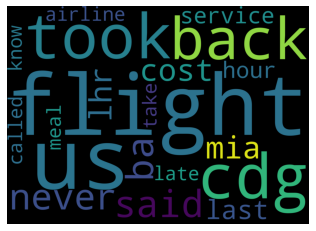

```python
#Generating the wordcloud with the values for Second topic
secondcloud = WordCloud(
                          stopwords=STOPWORDS,
                          background_color='black',
                          width=2500,
                          height=1800
                         ).generate(" ".join(second_topic_words))
plt.imshow(secondcloud)
plt.axis('off')
plt.show()
```

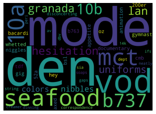

```python
# Generating the wordcloud with the values for third topic
thirdcloud = WordCloud(
                          stopwords=STOPWORDS,
                          background_color='black',
                          width=2500,
                          height=1800
                         ).generate(" ".join(third_topic_words))
plt.imshow(thirdcloud)
plt.axis('off')
plt.show()
```

[figure not shown]

```python
# Generating the wordcloud with the values for fouth topic
fourthcloud = WordCloud(
                          stopwords=STOPWORDS,
                          background_color='black',
                          width=2500,
                          height=1800
                         ).generate(" ".join(fourth_topic_words))
plt.imshow(fourthcloud)
plt.axis('off')
plt.show()
```

# 3.Sentiment Analysis

#### *For Sentiment Analysis, we’ll use VADER Sentiment Analysis, where VADER means Valence Aware Dictionary and sentiment Reasoner.

#### *VADER not only tells about the Polarity score , in addition, it tells us how positive or negative a statement is.

```python
def vadersentimentanalysis(review):
    vs = analyzer.polarity_scores(review)
    return vs['compound']

df['Sentiment'] = df['reviews'].apply(vadersentimentanalysis)


def vader_analysis(compound):
    if compound >= 0.5:
        return 'Positive'
    elif compound < 0 :
        return 'Negative'
    else:
        return 'Neutral'
df['Analysis'] = df['Sentiment'].apply(vader_analysis)
df.head()
```

|  | reviews | Sentiment | Analysis |
| --- | --- | --- | --- |
| 0 | old narrow pitch flight perfectly time constan... | 0.8934 | Positive |
| 1 | another ba shamble started well excellent chec... | 0.9682 | Positive |
| 2 | ba cancelled flight home heathrow dec th face ... | -0.9360 | Negative |
| 3 | ba cancelled flight home last flight day heath... | -0.5070 | Negative |
| 4 | turned hour advance terminal london heathrow a... | -0.6808 | Negative |

```python
analysis = df['Analysis'].value_counts()
analysis
```

```
Neutral     1754
Positive    1010
Negative     678
Name: Analysis, dtype: int64
```

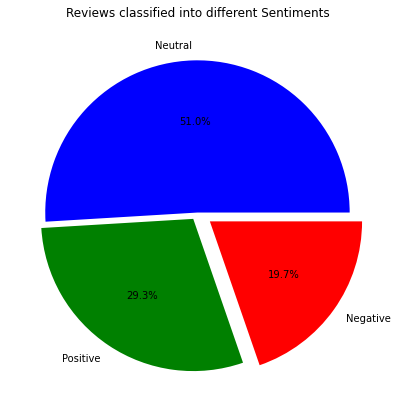

```python
plt.figure(figsize=(25,7))
plt.subplot(1,3,2)
plt.title("Reviews classified into different Sentiments")
plt.pie(analysis.values, labels = analysis.index, explode = (0, 0.05, 0.1), autopct='%1.1f%%', shadow=False , colors=("blue", "green", "red"))
plt.show()
```

# 4.Text Visualization

```python
all_words = df['reviews'].str.split(expand=True).unstack().value_counts()
data = [go.Bar(
            x = all_words.index.values[2:50],
            y = all_words.values[2:50],
            marker= dict(colorscale='Jet',
                         color = all_words.values[2:100]
                        ),
            text='Word counts'
    )]

layout = go.Layout(
    title='Top 50 Word frequencies in the dataset'
)

fig = go.Figure(data=data, layout=layout)

py.iplot(fig, filename='basic-bar')
```

[interactive chart not shown]

## 4.2.WordCloud of our dataset

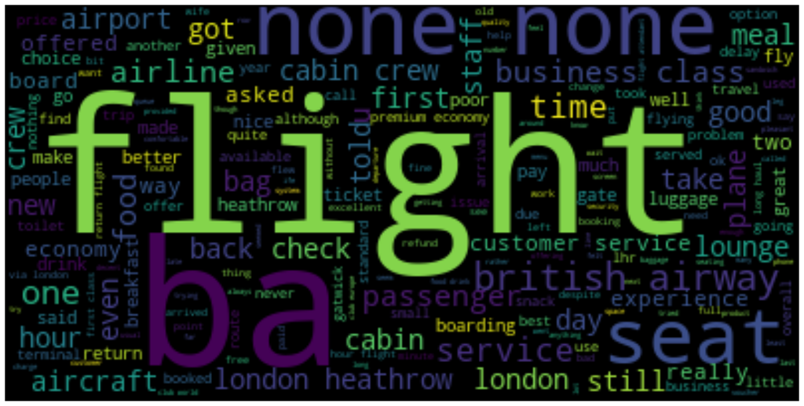

```python
text = " ".join(i for i in df.reviews)
wordcloud = WordCloud().generate(text)
fig = plt.figure(1, figsize=(20, 12))
plt.imshow(wordcloud, interpolation="bilinear")
plt.axis("off")
plt.show()
```